# Hybrid, Electric, Diesel? How has miles per gallon changed throughout the years?

By : Joel Samuel

### Intro / Motivation

In our world today, the use of cars has become ordinary and often neccessary in order to survive. But the basic function of the car is to take us further than we ever could just walking. How have we advanced? Are our cars getting better in terms of the miles we get per gallon? The better we get with our miles per gallon, the better our environment becomes as well. We all have heard about alternate fuels for our cars, but how effective are they? Diesel, hybrid, and electric vehicles are the most popular alternate fuels when it comes to cars. How effecient are they really and how have they changed throughout the years? Are we getting better? In this tutorial we aim to answer these questions.  
I believe that hybrid cars, since it utilizes both gas and electricity, that it would be able to get cars to go the farthest.

Documentation and Dataset Zip File :https://www.fueleconomy.gov/feg/ws/index.shtml#ft2  
*Note : electrical cars are measured in mpge, miles per gallon equivalent of electricity

### Data Collection

FuelEconomy.gov has a lot of data on cars and their fuel economy information. This information is provided by the US Department of energy. In order to get the dataset you first need to download the csv file from https://www.fueleconomy.gov/feg/ws/index.shtml#ft2, a file called vehicle.csv (unzipped). This csv file contains the fuel ecnomy information for 1984 - current model year vehicles. We can find the documentation for this csv file if you scroll down. Once downloaded use pandas in order to store the data into a nice clean dataframe

```python
# Importing neccessary modules
import pandas as pd
import numpy as np
import matplotlib.pyplot as plt
import seaborn
import statsmodels.api as sm
import statsmodels.formula.api as smf
```

```python
pd.set_option("display.max_rows", None, "display.max_columns", None)
# Read in the vehicles csv into a dataframe
df = pd.read_csv("vehicles.csv")
df.head(100)
```

[output not shown]

[output cut: 70 more lines]

### Data Management / Representation

Now we trim the dataframe to get the neccessary information needed to make our assumptions. First we sort the values by year and then by make in order to see the data based on the years. Then retrieve the data needed from the table, such as the make, model, mileage, etc. Hybrid and electric cars only started to coming into use 'lately' (late 90's) so we then trim the data to years only past 1995 to help make the data easier to look at and we still get data that pertains to the problem.

The dataframe should have the following features:  
**Make** :manufacturer  
**Model** :model  
**AtvType** :type of alternative fuel or advanced technology vehicle  
**City08** :city MPG  
**Year** :model year

```python
# Getting only needed columns
df_trim = df[['make','model','atvType','city08','year']].copy()
# Sorting the dataframe by year and make
df_trim = df_trim.sort_values(by=['year','make'])
# Dropping all years before 1995
df_trim = df_trim.drop(df_trim[df_trim['year'] < 1995].index)
df_trim.head()
```

|  | make | model | atvType | city08 | year |
| --- | --- | --- | --- | --- | --- |
| 1758 | Acura | NSX | NaN | 16 | 1995 |
| 1759 | Acura | NSX | NaN | 16 | 1995 |
| 1823 | Acura | Integra | NaN | 22 | 1995 |
| 1825 | Acura | Integra | NaN | 21 | 1995 |
| 1826 | Acura | Integra | NaN | 22 | 1995 |

### Exploratory Data Analysis

```python
# Getting the years to iterate over
years = df_trim['year'].drop_duplicates()
years.head()
```

```
1758    1995
2788    1996
3675    1997
4427    1998
5323    1999
Name: year, dtype: int64
```

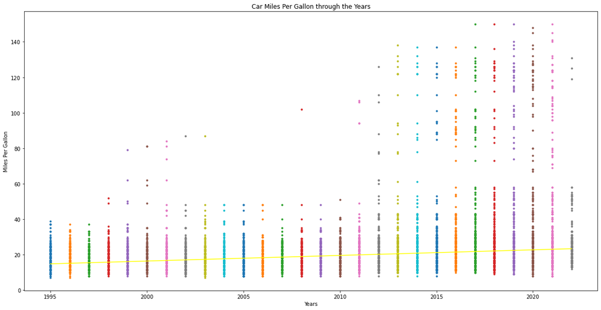

```python
# Iterate through each year
plt.subplots(figsize = (20,10))
for year in years:
    # Get the table for that year
    curr = df_trim.drop(df_trim[df_trim['year'] != year].index)
    # Plot the data for each year and the mpg
    plt.plot(curr['year'],curr['city08'],'.')
# Making plot pretty
plt.xlabel('Years')
plt.ylabel('Miles Per Gallon')
plt.title('Car Miles Per Gallon through the Years')
# Fitting best fit line
m,b = np.polyfit(df_trim['year'],df_trim['city08'],1)
plt.plot(df_trim['year'], m*(df_trim['year'])+b,color='yellow')
plt.savefig('CarMilesPerGallon.png')
```

Here is the data in a violin plot in order to show where the bulk of the data lies

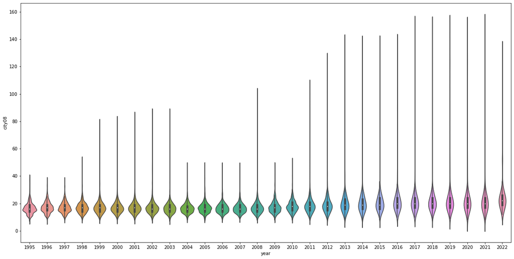

```python
# Using seaborn to plot the data as a violin plot
plt.subplots(figsize = (20,10))
seaborn.violinplot(x=df_trim['year'], y=df_trim['city08'])
```

##### Overall Look

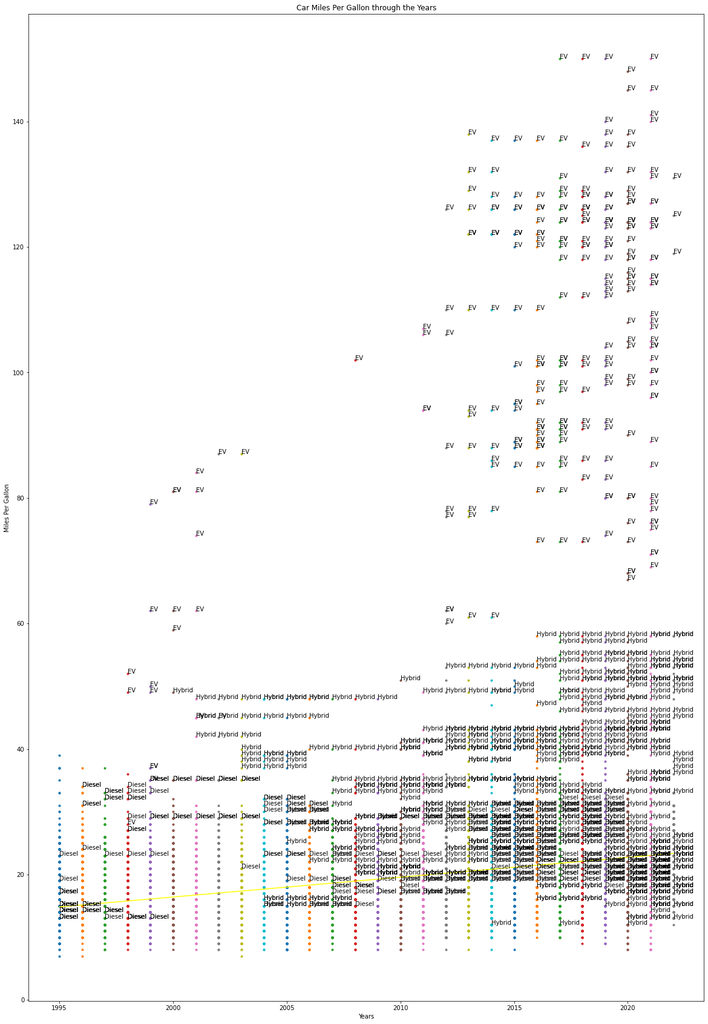

```python
# Getting the alternate fuel types
atvTypes =['Diesel','Hybrid','EV']
plt.subplots(figsize = (20,30))
# Iterate through each year
for year in years:
    # Getting the data for each year
    curr = df_trim.drop(df_trim[df_trim['year'] != year].index)
    # Plotting the mpg data for each year
    plt.plot(curr['year'],curr['city08'],'.')
    # Annotating each fuel type in the year
    for index, row in curr.iterrows():
        if row['atvType'] in atvTypes:
            plt.annotate(row['atvType'],(df_trim['year'][index],df_trim['city08'][index]))
# Making plot pretty
plt.xlabel('Years')
plt.ylabel('Miles Per Gallon')
plt.title('Car Miles Per Gallon through the Years')
# Plotting regression line
m,b = np.polyfit(df_trim['year'],df_trim['city08'],1)
plt.plot(df_trim['year'], m*(df_trim['year'])+b,color='yellow')
```

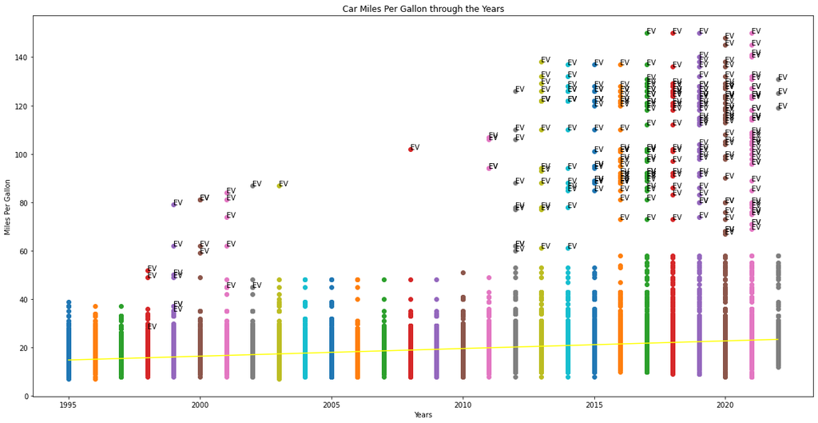

```python
# Annotating only electric vehicles for easier view
atvTypes =['EV']
plt.subplots(figsize = (20,10))
for year in years:
    curr = df_trim.drop(df_trim[df_trim['year'] != year].index)

    plt.plot(curr['year'],curr['city08'],'o')
    for index, row in curr.iterrows():
        if row['atvType'] in atvTypes:
            plt.annotate(row['atvType'],(df_trim['year'][index],df_trim['city08'][index]))
plt.xlabel('Years')
plt.ylabel('Miles Per Gallon')
plt.title('Car Miles Per Gallon through the Years')
m,b = np.polyfit(df_trim['year'],df_trim['city08'],1)
plt.plot(df_trim['year'], m*(df_trim['year'])+b,color='yellow')
```

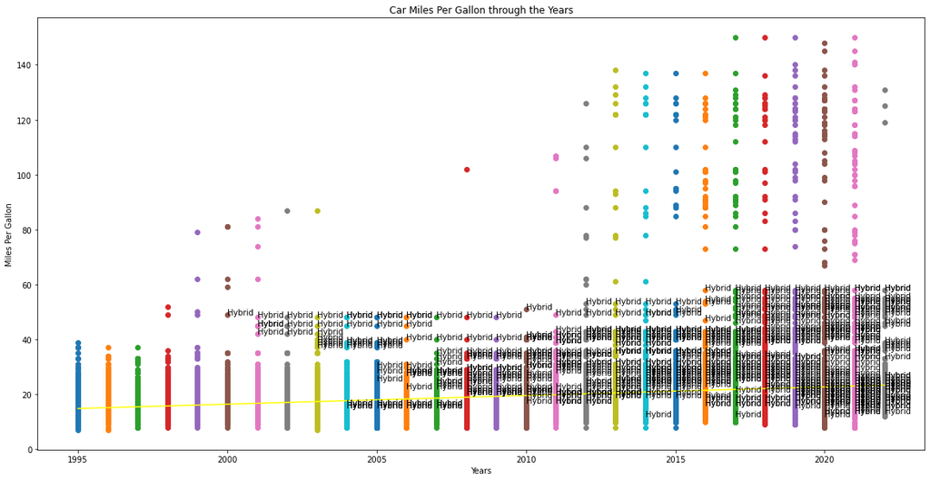

```python
# Annotating only hybrid vehicles for easier view
atvTypes =['Hybrid']
plt.subplots(figsize = (20,10))
for year in years:
    curr = df_trim.drop(df_trim[df_trim['year'] != year].index)

    plt.plot(curr['year'],curr['city08'],'o')
    for index, row in curr.iterrows():
        if row['atvType'] in atvTypes :
            plt.annotate(row['atvType'],(df_trim['year'][index],df_trim['city08'][index]))
plt.xlabel('Years')
plt.ylabel('Miles Per Gallon')
plt.title('Car Miles Per Gallon through the Years')
m,b = np.polyfit(df_trim['year'],df_trim['city08'],1)
plt.plot(df_trim['year'], m*(df_trim['year'])+b,color='yellow')
```

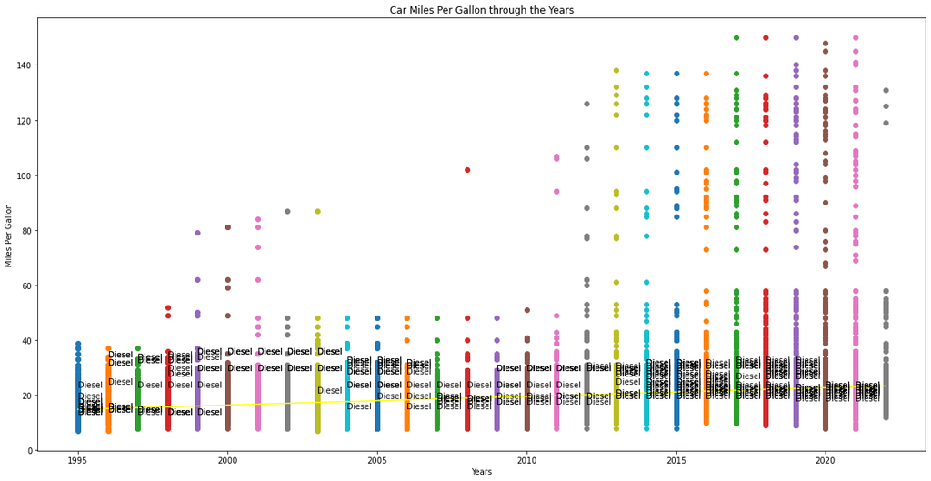

```python
# Annotating only diesel vehicles for easier view
atvTypes =['Diesel']
plt.subplots(figsize = (20,10))
for year in years:
    curr = df_trim.drop(df_trim[df_trim['year'] != year].index)

    plt.plot(curr['year'],curr['city08'],'o')
    for index, row in curr.iterrows():
        if row['atvType'] in atvTypes :
            plt.annotate(row['atvType'],(df_trim['year'][index],df_trim['city08'][index]))
plt.xlabel('Years')
plt.ylabel('Miles Per Gallon')
plt.title('Car Miles Per Gallon through the Years')
m,b = np.polyfit(df_trim['year'],df_trim['city08'],1)
plt.plot(df_trim['year'], m*(df_trim['year'])+b,color='yellow')
```

##### Specifics

Now I want to take only hybrid, diesel, and electric car data in order to compare between those three types and how they have changed throughout the years. I got the data for each year for the specific car types and plotted it against time. It is clear to see that as time progressed, overall mpg have increased.

```python
# Getting all data pertaining to hybrid, diesel, or electrical vehicles
df_types = df_trim[(df_trim.atvType == 'Hybrid')|(df_trim.atvType == 'EV')|(df_trim.atvType == 'Diesel')]
df_types.head()
```

|  | make | model | atvType | city08 | year |
| --- | --- | --- | --- | --- | --- |
| 2407 | Chevrolet | C1500 Pickup 2WD | Diesel | 15 | 1995 |
| 2408 | Chevrolet | C1500 Pickup 2WD | Diesel | 15 | 1995 |
| 2409 | Chevrolet | C1500 Pickup 2WD | Diesel | 17 | 1995 |
| 2418 | Chevrolet | Pickup 2500 2WD | Diesel | 14 | 1995 |
| 2419 | Chevrolet | Pickup 2500 2WD | Diesel | 15 | 1995 |

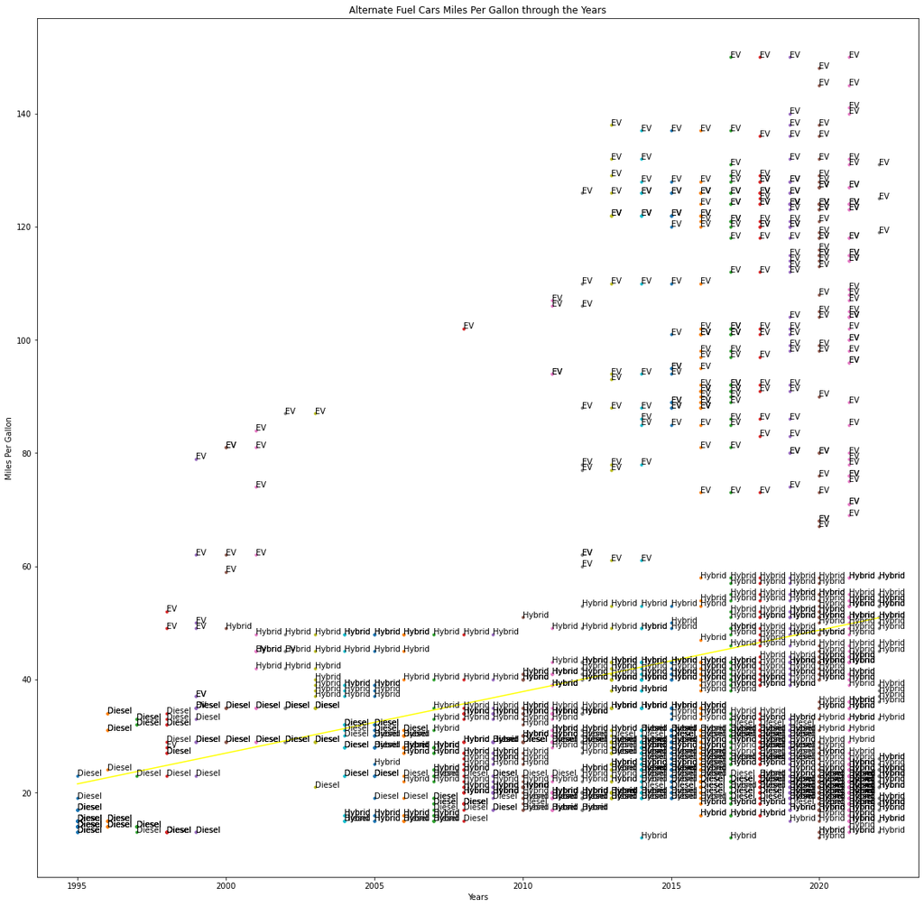

```python
# Iterate through each year
plt.subplots(figsize = (20,20))
for year in years:
    # Get the table for that year
    curr = df_types.drop(df_types[df_types['year'] != year].index)
    # Plot the data for each year and the mpg
    plt.plot(curr['year'],curr['city08'],'.')

    for index, row in curr.iterrows():
        plt.annotate(row['atvType'],(df_types['year'][index],df_types['city08'][index]))

# Making plot pretty
plt.xlabel('Years')
plt.ylabel('Miles Per Gallon')
plt.title('Alternate Fuel Cars Miles Per Gallon through the Years')
# Fitting best fit line
m,b = np.polyfit(df_types['year'],df_types['city08'],1)
plt.plot(df_types['year'], m*(df_types['year'])+b,color='yellow')
plt.savefig('CarMilesPerGallon.png')
```

We can now test our hypothesis on if year has a relationship with overall miles per gallon between our vehicle types. We can reject the null hypothesis of no relationship between year and miles per gallon with our linear regression model. After fitting the model to our data, we end up with a p value of 0.000 which means that our data is statistically significant and there is a relationship between miles per gallon and year.

```python
# Getting regression line by using statsmodel and ordinary least squares
x = sm.add_constant(df_types['year'])
y = df_types['city08']
estimate = sm.OLS(y,x)
est2 = estimate.fit()
print(est2.summary())
```

```
                            OLS Regression Results
==============================================================================
Dep. Variable:                 city08   R-squared:                       0.051
Model:                            OLS   Adj. R-squared:                  0.050
Method:                 Least Squares   F-statistic:                     84.18
Date:                Wed, 21 Jul 2021   Prob (F-statistic):           1.36e-19
Time:                        08:26:32   Log-Likelihood:                -7715.3
No. Observations:                1584   AIC:                         1.543e+04
Df Residuals:                    1582   BIC:                         1.545e+04
Df Model:                           1
Covariance Type:            nonrobust
==============================================================================
                 coef    std err          t      P>|t|      [0.025      0.975]
------------------------------------------------------------------------------
const      -2146.7085    238.586     -8.998      0.000   -2614.687   -1678.730
year           1.0868      0.118      9.175      0.000       0.854       1.319
==============================================================================
Omnibus:                      383.398   Durbin-Watson:                   1.043
Prob(Omnibus):                  0.000   Jarque-Bera (JB):              715.273
Skew:                           1.510   Prob(JB):                    4.79e-156
Kurtosis:                       4.311   Cond. No.                     6.06e+05
==============================================================================

Notes:
[1] Standard Errors assume that the covariance matrix of the errors is correctly specified.
[2] The condition number is large, 6.06e+05. This might indicate that there are
strong multicollinearity or other numerical problems.
```

Now lets see how each individual type of vehicle is affected by year. First I got the data pertaining to only hybrids and plotted it. After plotting, it seems like mpg for hybrids are kind of all over the place and not affected by year.

```python
# Getting all data pertaining to hybrid vehicles
df_hybrid = df_trim[df_trim.atvType == 'Hybrid']
df_hybrid.head()
```

|  | make | model | atvType | city08 | year |
| --- | --- | --- | --- | --- | --- |
| 6230 | Honda | Insight | Hybrid | 49 | 2000 |
| 7162 | Honda | Insight | Hybrid | 45 | 2001 |
| 7163 | Honda | Insight | Hybrid | 45 | 2001 |
| 7164 | Honda | Insight | Hybrid | 48 | 2001 |
| 7451 | Toyota | Prius | Hybrid | 42 | 2001 |

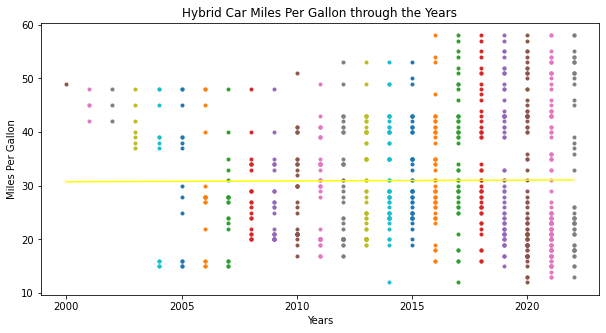

```python
# Iterate through each year
plt.subplots(figsize = (10,5))
for year in years:
    # Get the table for that year
    curr = df_hybrid.drop(df_hybrid[df_hybrid['year'] != year].index)
    # Plot the data for each year and the mpg
    plt.plot(curr['year'],curr['city08'],'.')


# Making plot pretty
plt.xlabel('Years')
plt.ylabel('Miles Per Gallon')
plt.title('Hybrid Car Miles Per Gallon through the Years')
# Fitting best fit line
m,b = np.polyfit(df_hybrid['year'],df_hybrid['city08'],1)
plt.plot(df_hybrid['year'], m*(df_hybrid['year'])+b,color='yellow')
plt.savefig('CarMilesPerGallon.png')
```

We can test the null hypothesis that there is no relationship between year and miles per gallon for hybrid cars. Using the regression line and fitting our hybrid mpg data to it, we find a p value of .84. This shows that our data is not statistically significant. For hybrid cars, there is no relationship between year and miles per gallon.

```python
# Getting regression line by using statsmodel and ordinary least squares
x = sm.add_constant(df_hybrid['year'])
y = df_hybrid['city08']
estimate = sm.OLS(y,x)
est2 = estimate.fit()
print(est2.summary())
```

```
                            OLS Regression Results
==============================================================================
Dep. Variable:                 city08   R-squared:                       0.000
Model:                            OLS   Adj. R-squared:                 -0.001
Method:                 Least Squares   F-statistic:                   0.04073
Date:                Wed, 21 Jul 2021   Prob (F-statistic):              0.840
Time:                        08:26:33   Log-Likelihood:                -3274.4
No. Observations:                 849   AIC:                             6553.
Df Residuals:                     847   BIC:                             6562.
Df Model:                           1
Covariance Type:            nonrobust
==============================================================================
                 coef    std err          t      P>|t|      [0.025      0.975]
------------------------------------------------------------------------------
const         -0.0188    153.605     -0.000      1.000    -301.509     301.471
year           0.0154      0.076      0.202      0.840      -0.134       0.165
==============================================================================
Omnibus:                      111.014   Durbin-Watson:                   0.809
Prob(Omnibus):                  0.000   Jarque-Bera (JB):               62.121
Skew:                           0.519   Prob(JB):                     3.24e-14
Kurtosis:                       2.176   Cond. No.                     7.87e+05
==============================================================================

Notes:
[1] Standard Errors assume that the covariance matrix of the errors is correctly specified.
[2] The condition number is large, 7.87e+05. This might indicate that there are
strong multicollinearity or other numerical problems.
```

```python
# Getting all data pertaining to diesel vehicles
df_diesel = df_trim[df_trim.atvType == 'Diesel']
df_diesel.head()
```

|  | make | model | atvType | city08 | year |
| --- | --- | --- | --- | --- | --- |
| 2407 | Chevrolet | C1500 Pickup 2WD | Diesel | 15 | 1995 |
| 2408 | Chevrolet | C1500 Pickup 2WD | Diesel | 15 | 1995 |
| 2409 | Chevrolet | C1500 Pickup 2WD | Diesel | 17 | 1995 |
| 2418 | Chevrolet | Pickup 2500 2WD | Diesel | 14 | 1995 |
| 2419 | Chevrolet | Pickup 2500 2WD | Diesel | 15 | 1995 |

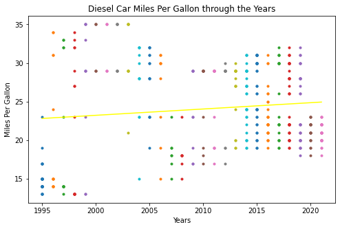

```python
# Iterate through each year
plt.subplots(figsize = (8,5))
for year in years:
    # Get the table for that year
    curr = df_diesel.drop(df_diesel[df_diesel['year'] != year].index)
    # Plot the data for each year and the mpg
    plt.plot(curr['year'],curr['city08'],'.')


# Making plot pretty
plt.xlabel('Years')
plt.ylabel('Miles Per Gallon')
plt.title('Diesel Car Miles Per Gallon through the Years')
# Fitting best fit line
m,b = np.polyfit(df_diesel['year'],df_diesel['city08'],1)
plt.plot(df_diesel['year'], m*(df_diesel['year'])+b,color='yellow')
plt.savefig('CarMilesPerGallon.png')
```

We then can reject the null hypothesis, again by using our linear regression model. After fitting the diesel mpg data, we see that there is a p value of .014 which means that the data is statistically significant. There is a relationship between mpg for diesel cars and time.

```python
# Getting regression line by using statsmodel and ordinary least squares
x = sm.add_constant(df_diesel['year'])
y = df_diesel['city08']
estimate = sm.OLS(y,x)
est2 = estimate.fit()
print(est2.summary())
```

```
                            OLS Regression Results
==============================================================================
Dep. Variable:                 city08   R-squared:                       0.014
Model:                            OLS   Adj. R-squared:                  0.011
Method:                 Least Squares   F-statistic:                     6.114
Date:                Wed, 21 Jul 2021   Prob (F-statistic):             0.0138
Time:                        08:26:33   Log-Likelihood:                -1428.8
No. Observations:                 448   AIC:                             2862.
Df Residuals:                     446   BIC:                             2870.
Df Model:                           1
Covariance Type:            nonrobust
==============================================================================
                 coef    std err          t      P>|t|      [0.025      0.975]
------------------------------------------------------------------------------
const       -140.1098     66.404     -2.110      0.035    -270.613      -9.607
year           0.0817      0.033      2.473      0.014       0.017       0.147
==============================================================================
Omnibus:                      136.019   Durbin-Watson:                   0.615
Prob(Omnibus):                  0.000   Jarque-Bera (JB):               23.357
Skew:                           0.142   Prob(JB):                     8.47e-06
Kurtosis:                       1.918   Cond. No.                     4.80e+05
==============================================================================

Notes:
[1] Standard Errors assume that the covariance matrix of the errors is correctly specified.
[2] The condition number is large, 4.8e+05. This might indicate that there are
strong multicollinearity or other numerical problems.
```

Finally we plot the data for electrical vehicles and their mpg. It is very clear to see that as the years have progressed, electrical vehicles have been getting higher mpg.

```python
# Getting all data pertaining to electrical vehicles
df_ev = df_trim[df_trim.atvType == 'EV']
df_ev.head()
```

|  | make | model | atvType | city08 | year |
| --- | --- | --- | --- | --- | --- |
| 23028 | Chevrolet | S10 Electric | EV | 52 | 1998 |
| 23029 | Chevrolet | S10 Electric | EV | 28 | 1998 |
| 23027 | Honda | EV Plus | EV | 49 | 1998 |
| 23025 | Dodge | Caravan/Grand Caravan 2WD | EV | 37 | 1999 |
| 23023 | Ford | Ranger Pickup 2WD | EV | 62 | 1999 |

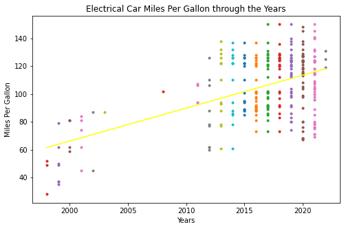

```python
# Iterate through each year
plt.subplots(figsize = (8,5))
for year in years:
    # Get the table for that year
    curr = df_ev.drop(df_ev[df_ev['year'] != year].index)
    # Plot the data for each year and the mpg
    plt.plot(curr['year'],curr['city08'],'.')


# Making plot pretty
plt.xlabel('Years')
plt.ylabel('Miles Per Gallon')
plt.title('Electrical Car Miles Per Gallon through the Years')
# Fitting best fit line
m,b = np.polyfit(df_ev['year'],df_ev['city08'],1)
plt.plot(df_ev['year'], m*(df_ev['year'])+b,color='yellow')
plt.savefig('CarMilesPerGallon.png')
```

Fitting the electrical vehicle data to our linear regression line, we can clearly reject the null hypothesis that there is no relationship between electrical mpg and year. The p value is 0.000 which means that our data is statistically significant and that there is a relationship between electrical vehicle mpg and year.

```python
# Getting regression line by using statsmodel and ordinary least squares
x = sm.add_constant(df_ev['year'])
y = df_ev['city08']
estimate = sm.OLS(y,x)
est2 = estimate.fit()
print(est2.summary())
```

```
                            OLS Regression Results
==============================================================================
Dep. Variable:                 city08   R-squared:                       0.281
Model:                            OLS   Adj. R-squared:                  0.279
Method:                 Least Squares   F-statistic:                     111.7
Date:                Wed, 21 Jul 2021   Prob (F-statistic):           3.07e-22
Time:                        08:26:34   Log-Likelihood:                -1273.4
No. Observations:                 287   AIC:                             2551.
Df Residuals:                     285   BIC:                             2558.
Df Model:                           1
Covariance Type:            nonrobust
==============================================================================
                 coef    std err          t      P>|t|      [0.025      0.975]
------------------------------------------------------------------------------
const      -4655.2017    450.436    -10.335      0.000   -5541.806   -3768.598
year           2.3607      0.223     10.567      0.000       1.921       2.800
==============================================================================
Omnibus:                       16.382   Durbin-Watson:                   1.322
Prob(Omnibus):                  0.000   Jarque-Bera (JB):                8.942
Skew:                          -0.252   Prob(JB):                       0.0114
Kurtosis:                       2.298   Cond. No.                     7.50e+05
==============================================================================

Notes:
[1] Standard Errors assume that the covariance matrix of the errors is correctly specified.
[2] The condition number is large, 7.5e+05. This might indicate that there are
strong multicollinearity or other numerical problems.
```

I then plotted each alternate fuel type car again, however I added each specific alternate fuel regression lines in order to see how they differed in one plot. We see that the average diesal miles per gallon is far below the average electrical and hybrid miles per gallon. The hybrid regression line we found was not statistically significant but regardless we are able to see the electrical vehicle regression line which is far steeper and much higher than diesel and hybrid car miles per gallon. This plot helps to show just how good electrical vehicles have gotten in terms of miles per gallon.

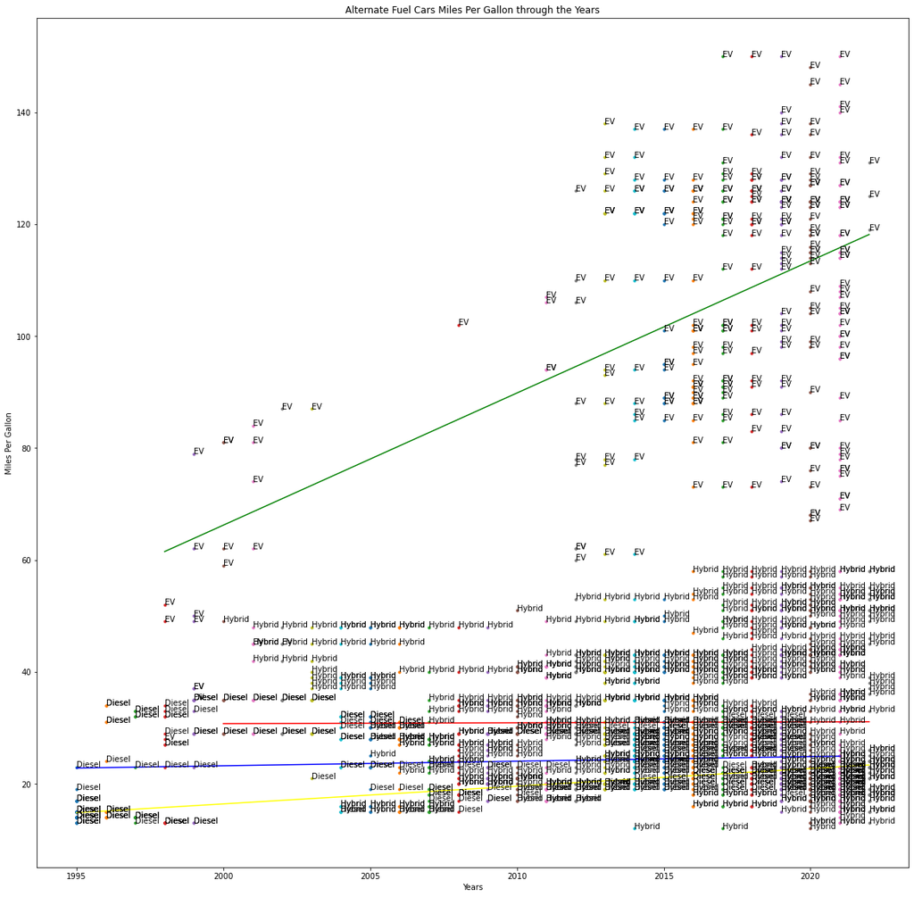

```python
# Getting all data pertaining to hybrid, diesel, or electrical vehicles
df_types = df_trim[(df_trim.atvType == 'Hybrid')|(df_trim.atvType == 'EV')|(df_trim.atvType == 'Diesel')]
# Iterate through each year
plt.subplots(figsize = (20,20))
for year in years:
    # Get the table for that year
    curr = df_types.drop(df_types[df_types['year'] != year].index)
    # Plot the data for each year and the mpg
    plt.plot(curr['year'],curr['city08'],'.')

    for index, row in curr.iterrows():
        plt.annotate(row['atvType'],(df_types['year'][index],df_types['city08'][index]))

# Making plot pretty
plt.xlabel('Years')
plt.ylabel('Miles Per Gallon')
plt.title('Alternate Fuel Cars Miles Per Gallon through the Years')
# Fitting best fit line for hybrid cars
m,b = np.polyfit(df_hybrid['year'],df_hybrid['city08'],1)
plt.plot(df_hybrid['year'], m*(df_hybrid['year'])+b,color='red')
# Fitting best fit line for diesel cars
m,b = np.polyfit(df_diesel['year'],df_diesel['city08'],1)
plt.plot(df_diesel['year'], m*(df_diesel['year'])+b,color='blue')
# Fitting best fit line for electrical cars
m,b = np.polyfit(df_ev['year'],df_ev['city08'],1)
plt.plot(df_ev['year'], m*(df_ev['year'])+b,color='green')
# Fitting best fit line for all cars
m,b = np.polyfit(df_trim['year'],df_trim['city08'],1)
plt.plot(df_trim['year'], m*(df_trim['year'])+b,color='yellow')
plt.savefig('CarMilesPerGallon.png')
```

### Insights / Conclusion

For all cars, we see that there is an increase of miles per gallon throughout the years. However, there is not a significant change for the average car miles per gallon. We see that the average car fuel economy stays around 20 miles per gallon from 1995 to today. Diesel cars while slightly better than the average car fuel economy, has not increased by much throughout the years. The one that surprised me was the hybrid cars. While there are some hybrid cars that boast great fuel economy, there are also a good amount of hybrid cars that are below the average car fuel economy. So we see that in the case for most cars, there has not been significant improvement through the years. This shows that in the case for most cars, they are not looking to enhance its performance when it comes to miles per gallon. The only car that has significant increase was the electrical car. We can see very clearly, that electrical cars have been improving in terms of miles per gallon throughout the years. We can see that out of all the alternate fuel types, electrical vehicles are by far the most efficient car and have improved the most throughout the years. Diesel has improved throughout the years, but not by much and in terms of alternate fuels, it is one of the less efficient fuels. Hybrid cars on the other hand have not really improved as a whole and individual cars can be seen varying in terms of efficiency. Overall, while we may think that we are getting better and more efficient cars, most cars have not improved throughout the years in terms of miles per gallon.